# Weekly Sales Forecast for Big Box, Inc.

Big Box, Inc. requested a forecast of weekly sales for the individual deparments in each of its stores. The company provided the data team with three CSV files containing data related to its stores and their departments, weekly sales, and economic and weather conditions in the geographic areas where stores are located. Specifically Big Box requested a forecast of the next three months beyond the actual sales data provided.

We performed a time series analysis through the following phases:

# Time Series Analysis Phases

1. [Data Import, Validation, and Merge](https://mstuartproj.github.io/sales_forecast/Sales_Forecast_1.html)
2. [Exploratory Data Analysis: Stores, Departments, and Total Sales](https://mstuartproj.github.io/sales_forecast/Sales_Forecast_2.html)
3. [Exploratory Data Analysis: Weekly Sales](https://mstuartproj.github.io/sales_forecast/Sales_Forecast_3.html)
4. [Feature Creation and Selection](https://mstuartproj.github.io/sales_forecast/Sales_Forecast_4.html)
5. [Modeling and Prediction: Random Forest Regression](https://mstuartproj.github.io/sales_forecast/Sales_Forecast_5.html)
6. [Modeling and Prediction: SARIMA](https://mstuartproj.github.io/sales_forecast/Sales_Forecast_6.html)

[figure not shown]

# Phase 5. Modeling and Prediction: Random Forest Regression

We used the RandomForestRegressor from the Python scikit-learn library for our model.

## Choosing the Number of Estimators

We tested different models by selecting different numbers of decision tree estimators (20, 30, 40, and 50). We saw that between 20 and 30 estimators there was a decrease in RMSE and an increase in R-Square. However continuing to increase the number of estimators beyond 30 did not appear to improve the performance further. Therefore we chose the model containing 30 estimators and proceeded with the analysis.

A sample run of the model generated these performance metrics including 95% accuracy (R-square):

[figure not shown]

```python
import matplotlib.pyplot as plt
import matplotlib.ticker as tick
import numpy as np
import pandas as pd
from sklearn.ensemble import RandomForestRegressor
from sklearn.metrics import mean_absolute_error
from sklearn.metrics import mean_squared_error
from sklearn.metrics import r2_score
from datetime import datetime
```

```python
#Read in the collected metrics on different number of estimators
metrics = pd.read_csv('data_merged/rf_metrics_diff_num_est.csv', index_col = 0)
```

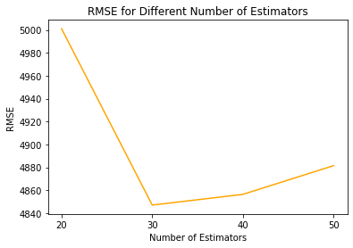

```python
#Plot the RMSE values for different number of estimators
plt.xlabel('Number of Estimators')
plt.ylabel('RMSE')
plt.title('RMSE for Different Number of Estimators')
plt.xticks(np.arange(10, 110, 10))
plt.plot(metrics['Num_Estimators'],metrics['RMSE'], color='orange')
```

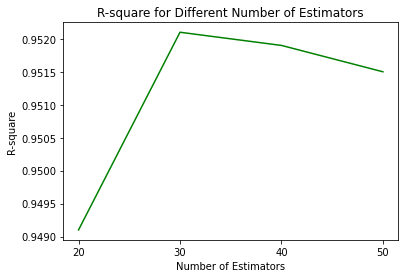

```python
#Plot the R-square values for different number of estimators
plt.xlabel('Number of Estimators')
plt.ylabel('R-square')
plt.title('R-square for Different Number of Estimators')
plt.xticks(np.arange(10, 110, 10))
plt.plot(metrics['Num_Estimators'],metrics['R-square'], color='green')
```

[figure not shown]

## Model Fitting and Evaluation

We prepared our training features and target values (x_train, y_train) as well as our validation features and target values (x_test, y_test). We then fit our model and used it to generate weekly sales predictions for the weeks in the validation set. We calculate several metrics to gauge how close the predicted sales were to the actual sales.

One prediction run produced the following overall metrics for all stores and all departments, including an accuracy of 95% (R-square = 0.95) which is very good.

> NOTE: The metrics should also be examined for model performance on individual stores and deparments.

[figure not shown]

```python
#Read in the training set that has no dates
trainingset = pd.read_csv('data_merged/trainingdata.csv', index_col = 0)
trainingset.head()
```

|  | Store | Dept | Weekly_Sales | Size | Temperature | Fuel_Price | CPI | Unemployment | Year | WeekNum | IsHolidayInt | TypeA | TypeB | TypeC |
| --- | --- | --- | --- | --- | --- | --- | --- | --- | --- | --- | --- | --- | --- | --- |
| 0 | 1 | 1 | 24924.50 | 151315 | 42.31 | 2.572 | 211.096358 | 8.106 | 2010 | 5 | 0 | 1.0 | 0.0 | 0.0 |
| 1 | 1 | 1 | 46039.49 | 151315 | 38.51 | 2.548 | 211.242170 | 8.106 | 2010 | 6 | 1 | 1.0 | 0.0 | 0.0 |
| 2 | 1 | 1 | 41595.55 | 151315 | 39.93 | 2.514 | 211.289143 | 8.106 | 2010 | 7 | 0 | 1.0 | 0.0 | 0.0 |
| 3 | 1 | 1 | 19403.54 | 151315 | 46.63 | 2.561 | 211.319643 | 8.106 | 2010 | 8 | 0 | 1.0 | 0.0 | 0.0 |
| 4 | 1 | 1 | 21827.90 | 151315 | 46.50 | 2.625 | 211.350143 | 8.106 | 2010 | 9 | 0 | 1.0 | 0.0 | 0.0 |

```python
#Read in the validation set that has no dates
validationset = pd.read_csv('data_merged/validationdata.csv', index_col = 0)
validationset.head()
```

|  | Store | Dept | Weekly_Sales | Size | Temperature | Fuel_Price | CPI | Unemployment | Year | WeekNum | IsHolidayInt | TypeA | TypeB | TypeC |
| --- | --- | --- | --- | --- | --- | --- | --- | --- | --- | --- | --- | --- | --- | --- |
| 0 | 1 | 1 | 57592.12 | 151315 | 70.43 | 3.891 | 221.435611 | 7.143 | 2012 | 14 | 0 | 1.0 | 0.0 | 0.0 |
| 1 | 1 | 1 | 34684.21 | 151315 | 69.07 | 3.891 | 221.510210 | 7.143 | 2012 | 15 | 0 | 1.0 | 0.0 | 0.0 |
| 2 | 1 | 1 | 16976.19 | 151315 | 66.76 | 3.877 | 221.564074 | 7.143 | 2012 | 16 | 0 | 1.0 | 0.0 | 0.0 |
| 3 | 1 | 1 | 16347.60 | 151315 | 67.23 | 3.814 | 221.617937 | 7.143 | 2012 | 17 | 0 | 1.0 | 0.0 | 0.0 |
| 4 | 1 | 1 | 17147.44 | 151315 | 75.55 | 3.749 | 221.671800 | 7.143 | 2012 | 18 | 0 | 1.0 | 0.0 | 0.0 |

```python
#Separate the features from the target values in the training set
x_train = trainingset.copy(deep=True)
x_train = x_train.drop(['Weekly_Sales'], axis=1)
y_train = trainingset['Weekly_Sales']

#Separate the features from the target values in the validation set
x_test = validationset.copy(deep=True)
x_test = x_test.drop(['Weekly_Sales'], axis=1)
y_test = validationset['Weekly_Sales']
```

```python
#Use 30 estimators to fit our model
estimator_count = 30
regression = RandomForestRegressor(n_estimators=estimator_count)
regression.fit(x_train, y_train)
y_pred = regression.predict(x_test)
```

```python
#Calculate and print performance metrics
metric_mean_sqr_err = mean_squared_error(y_test, y_pred)
metric_root_mean_sqr_err = np.sqrt(mean_squared_error(y_test, y_pred))
metric_mean_abs_err = mean_absolute_error(y_test, y_pred)
metric_r2_score = r2_score(y_test, y_pred)

print('Mean Squared Error (MSE) = ' + "{:.0f}".format(metric_mean_sqr_err))
print('Root Mean Square Error (RMSE) = ' + "{:.0f}".format(metric_root_mean_sqr_err))
print('Mean Absolute Error (MAE) = ' + "{:.0f}".format(metric_mean_abs_err))
print('R-square = ' + "{:.4f}".format(metric_r2_score))
```

```
Mean Squared Error (MSE) = 25000950
Root Mean Square Error (RMSE) = 5000
Mean Absolute Error (MAE) = 2254
R-square = 0.9491
```

```python
#Save the predictions for later comparison with actual sales
pred_validation_dates = pd.DataFrame(y_pred)
pred_validation_dates.columns =['Predicted_Weekly_Sales']
pred_validation_dates.to_csv('data_merged/predictions_validationdates.csv')
```

[figure not shown]

## Comparing Predicted Versus Actual Sales

We created a function to plot predicted versus actual weekly sales. We created one plot to compare the predictions against the validation set. Then we created a second plot to visualize the predictions against the entire range of available dates. Here we examined the same three departments that we analyzed in the Exploratory Data Analysis phase:

[figure not shown]

```python
#Function to plot predicted vs actual weekly sales
#for one deparment in one store
def plot_pred_vs_actual_sales_for_onestore(actualdates,
                                           actualsales,
                                           preddates,
                                           predsales,
                                           storenum,
                                           deptnum,
                                           x_date_spacing=1):
    plt.figure(figsize=(10, 5))
    plt.xlabel('Week')
    plt.ylabel('Weekly Sales ($)')
    plt.title('Actual and Predicted Weekly Sales for Store #' + str(storenum) +
              " Dept #" + str(deptnum))
    plt.xticks(np.arange(0, len(actualsales)+1, x_date_spacing))
    plt.xticks(rotation=45)
    plt.plot(actualdates,
             actualsales,
             label='Actual Weekly Sales')
    plt.plot(preddates,
             predsales,
             label='Predicted Weekly Sales', color='magenta')
    plt.legend()
    ax = plt.gca()
    ax.yaxis.set_major_formatter(tick.FuncFormatter(lambda x, p: format(int(x), ',')));
```

```python
#Read in the full data set for the entire range of weeks
fulldata_alldates = pd.read_csv('data_merged/fulldataset.csv',
                                index_col = 0)
#Read in the validation set with dates
validationset_withdates = pd.read_csv('data_merged/validationdata_withdates.csv',
                                      index_col = 0)
#Read in the predictions
predictions = pd.read_csv('data_merged/predictions_validationdates.csv',
                          index_col = 0)
```

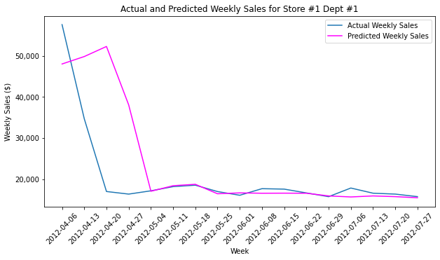

```python
#Plot Store 1 Department 1
onestorenum = 1
onedeptnum = 1

#Plot only the validation weeks
onestoredata = validationset_withdates.copy(deep=True)
onestoredata['Predicted_Weekly_Sales'] = predictions
onestoredata = onestoredata.loc[onestoredata['Store'] == onestorenum]
onedeptdata = onestoredata.loc[onestoredata['Dept'] == onedeptnum]
plot_pred_vs_actual_sales_for_onestore(onedeptdata['Date'],
                                       onedeptdata['Weekly_Sales'],
                                       onedeptdata['Date'],
                                       onedeptdata['Predicted_Weekly_Sales'],
                                       onestorenum,
                                       onedeptnum)
```

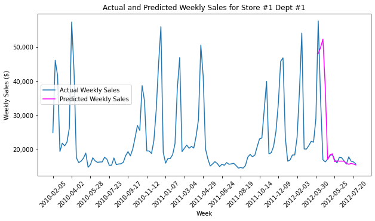

```python
#Plot the entire range of weeks
onestoredata_allweeks = fulldata_alldates.copy(deep=True)
onestoredata_allweeks = onestoredata_allweeks.loc[
    onestoredata_allweeks['Store'] == onestorenum]
onedeptdata_allweeks = onestoredata_allweeks.loc[onestoredata_allweeks['Dept'] == onedeptnum]
plot_pred_vs_actual_sales_for_onestore(onedeptdata_allweeks['Date'],
                                       onedeptdata_allweeks['Weekly_Sales'],
                                       onedeptdata['Date'],
                                       onedeptdata['Predicted_Weekly_Sales'],
                                       onestorenum,
                                       onedeptnum,
                                       x_date_spacing=8)
```

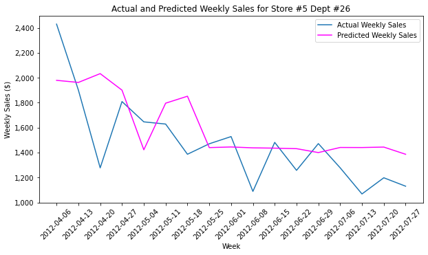

```python
#Plot Store 5 Department 26
onestorenum = 5
onedeptnum = 26

#Plot only the validation weeks
onestoredata = validationset_withdates.copy(deep=True)
onestoredata['Predicted_Weekly_Sales'] = predictions
onestoredata = onestoredata.loc[onestoredata['Store'] == onestorenum]
onedeptdata = onestoredata.loc[onestoredata['Dept'] == onedeptnum]
plot_pred_vs_actual_sales_for_onestore(onedeptdata['Date'],
                                       onedeptdata['Weekly_Sales'],
                                       onedeptdata['Date'],
                                       onedeptdata['Predicted_Weekly_Sales'],
                                       onestorenum,
                                       onedeptnum)
```

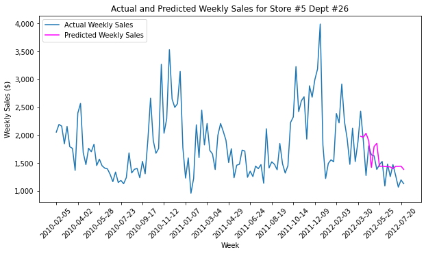

```python
#Plot the entire range of weeks
onestoredata_allweeks = fulldata_alldates.copy(deep=True)
onestoredata_allweeks = onestoredata_allweeks.loc[
    onestoredata_allweeks['Store'] == onestorenum]
onedeptdata_allweeks = onestoredata_allweeks.loc[onestoredata_allweeks['Dept'] == onedeptnum]
plot_pred_vs_actual_sales_for_onestore(onedeptdata_allweeks['Date'],
                                       onedeptdata_allweeks['Weekly_Sales'],
                                       onedeptdata['Date'],
                                       onedeptdata['Predicted_Weekly_Sales'],
                                       onestorenum,
                                       onedeptnum,
                                       x_date_spacing=8)
```

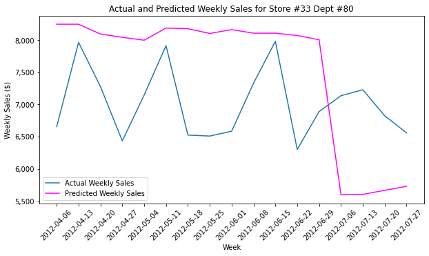

```python
#Plot Store 33 Department 80
onestorenum = 33
onedeptnum = 80

#Plot only the validation weeks
onestoredata = validationset_withdates.copy(deep=True)
onestoredata['Predicted_Weekly_Sales'] = predictions
onestoredata = onestoredata.loc[onestoredata['Store'] == onestorenum]
onedeptdata = onestoredata.loc[onestoredata['Dept'] == onedeptnum]
plot_pred_vs_actual_sales_for_onestore(onedeptdata['Date'],
                                       onedeptdata['Weekly_Sales'],
                                       onedeptdata['Date'],
                                       onedeptdata['Predicted_Weekly_Sales'],
                                       onestorenum,
                                       onedeptnum)
```

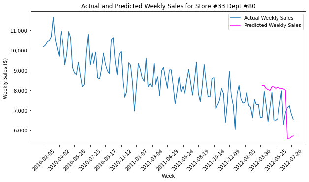

```python
#Plot the entire range of weeks
onestoredata_allweeks = fulldata_alldates.copy(deep=True)
onestoredata_allweeks = onestoredata_allweeks.loc[
    onestoredata_allweeks['Store'] == onestorenum]
onedeptdata_allweeks = onestoredata_allweeks.loc[onestoredata_allweeks['Dept'] == onedeptnum]
plot_pred_vs_actual_sales_for_onestore(onedeptdata_allweeks['Date'],
                                       onedeptdata_allweeks['Weekly_Sales'],
                                       onedeptdata['Date'],
                                       onedeptdata['Predicted_Weekly_Sales'],
                                       onestorenum,
                                       onedeptnum,
                                       x_date_spacing=8)
```

[figure not shown]

## Feature Importance Evaluation

The Random Forest Regressor provides a metric for the importance of each of the features in predicting weekly sales. We found that the department is by far the most important feature, followed by the size of the store. All of the other features have much lower importance scores. See the table and graph below.

Features associated with the area surrounding the store, such as the unemployment rate, the weekly temperature, and fuel price, are less important than the department and store size.

An example run of model fitting determined that these were the top four features and their assigned importance scores:

1. Department -- 0.615
2. Size -- 0.193
3. WeekNum -- 0.060
4. Store -- 0.050

[figure not shown]

```python
#Examine the feature importance ordered by descending score
importance = pd.DataFrame(x_train.columns,columns=["Feature"])
importance['Score'] = pd.DataFrame(regression.feature_importances_)
importance.sort_values(by=['Score'], inplace=True, ascending=False)
importance.reset_index(inplace=True, drop=True)
importance.head(15)
```

|  | Feature | Score |
| --- | --- | --- |
| 0 | Dept | 0.612766 |
| 1 | Size | 0.193410 |
| 2 | WeekNum | 0.059914 |
| 3 | Store | 0.051064 |
| 4 | CPI | 0.032155 |
| 5 | Unemployment | 0.013948 |
| 6 | Temperature | 0.012679 |
| 7 | TypeB | 0.010597 |
| 8 | Fuel_Price | 0.006558 |
| 9 | TypeA | 0.003344 |
| 10 | IsHolidayInt | 0.002526 |
| 11 | Year | 0.000611 |
| 12 | TypeC | 0.000429 |

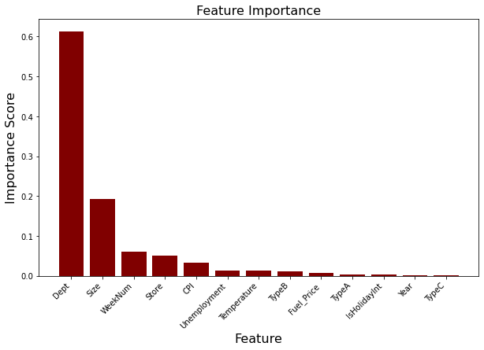

```python
#Graph by descending score
plt.figure(figsize=(10,6))
plt.bar(importance['Feature'], importance['Score'],color='maroon')
plt.xlabel("Feature", size=16)
plt.ylabel("Importance Score", size=16)
plt.title("Feature Importance", size=16)
plt.setp(plt.gca().get_xticklabels(), rotation=45, horizontalalignment='right')
plt.show()
```